# Assignment 2

Eva He, Sarah Xi, Zhijing Zhao

11/4/2019

```r
library(tidyverse)
library(lubridate)
library(data.table)
```

## Part 1

```r
# readin data and change the data type of each variable based on instructions
data_orig <- read_csv("https://s3.amazonaws.com/notredame.analytics.data/inspections.csv", col_types = cols(
  `Inspection ID` = col_integer(),
  `DBA Name` = col_character(),
  `AKA Name` = col_character(),
   `License #` = col_character(),
  `Facility Type` = col_factor(),
  Risk = col_factor(),
  Address = col_character(),
  City = col_factor(),
  State = col_factor(),
  Zip  = col_factor(),
  `Inspection Date` = col_character(),
  `Inspection Type` = col_factor(),
  Results = col_factor(),
  Violations = col_character(),
  Latitude = col_double(),
  Longitude = col_double(),
  Location = col_character()))

# change the name of certain variables
colnames(data_orig)[1] <- "ID"
colnames(data_orig)[4] <- "License"
colnames(data_orig)[10] <- "ZIP"
colnames(data_orig) <- str_replace_all(colnames(data_orig)," ","")

# change the datatype for InspectionDate
data_orig$InspectionDate <- mdy(data_orig$InspectionDate)

# get the summary for the dataset
summary(data_orig)
```

```
##        ID            DBAName            AKAName
##  Min.   :  44247   Length:140954      Length:140954
##  1st Qu.: 634864   Class :character   Class :character
##  Median :1343592   Mode  :character   Mode  :character
##  Mean   :1200306
##  3rd Qu.:1546533
##  Max.   :2014211
##
##    License                                   FacilityType
##  Length:140954      Restaurant                     :95265
##  Class :character   Grocery Store                  :19667
##  Mode  :character   School                         : 9136
##                     Daycare (2 - 6 Years)          : 2319
##                     Bakery                         : 2130
##                     Daycare Above and Under 2 Years: 1609
##                     (Other)                        :10828
##               Risk          Address                City
##  Risk 1 (High)  :100177   Length:140954      CHICAGO :140390
##  Risk 3 (Low)   : 10874   Class :character   Chicago :   244
##  Risk 2 (Medium): 29900   Mode  :character   chicago :    75
##  All            :     3                      CCHICAGO:    37
##                                              MAYWOOD :    12
##                                              (Other) :   147
##                                              NA's    :    49
##   State             ZIP         InspectionDate
##  IL  :140946   60614  :  5266   Min.   :2010-01-04
##  NA's:     8   60647  :  4874   1st Qu.:2011-12-28
##                60657  :  4748   Median :2013-11-08
##                60611  :  4577   Mean   :2013-10-10
##                60622  :  4549   3rd Qu.:2015-08-11
##                (Other):116934   Max.   :2017-03-17
##                NA's   :     6
##                InspectionType                  Results
##  Canvass              :73544   Pass                :85484
##  License              :18255   Out of Business     : 9562
##  Canvass Re-Inspection:14565   Fail                :27793
##  Complaint            :13026   Pass w/ Conditions  :13706
##  License Re-Inspection: 6831   No Entry            : 3778
##  Short Form Complaint : 5521   Not Ready           :  595
##  (Other)              : 9212   Business Not Located:   36
##   Violations           Latitude       Longitude        Location
##  Length:140954      Min.   :41.64   Min.   :-87.91   Length:140954
##  Class :character   1st Qu.:41.83   1st Qu.:-87.71   Class :character
##  Mode  :character   Median :41.89   Median :-87.67   Mode  :character
##                     Mean   :41.88   Mean   :-87.68
##                     3rd Qu.:41.94   3rd Qu.:-87.63
##                     Max.   :42.02   Max.   :-87.53
##                     NA's   :494     NA's   :494
```

```r
head(data_orig)
```

```
## # A tibble: 6 x 17
##       ID DBAName AKAName License FacilityType Risk  Address City  State
##    <int> <chr>   <chr>   <chr>   <fct>        <fct> <chr>   <fct> <fct>
## 1 2.00e6 SUBWAY  SUBWAY  1679112 Restaurant   Risk… 8711 S… CHIC… IL
## 2 2.00e6 VENEZU… VENEZU… 2424110 Restaurant   Risk… 2436 N… CHIC… IL
## 3 2.00e6 SEVEN … SEVEN … 1172093 Restaurant   Risk… 1055 E… CHIC… IL
## 4 2.00e6 CHISME… CHISME… 1334960 Restaurant   Risk… 5955 S… CHIC… IL
## 5 2.00e6 THE NI… THE NI… 2334190 Restaurant   Risk… 1162 E… CHIC… IL
## 6 2.00e6 WINGST… WINGST… 2517730 Restaurant   Risk… 850 W … CHIC… IL
## # … with 8 more variables: ZIP <fct>, InspectionDate <date>,
## #   InspectionType <fct>, Results <fct>, Violations <chr>, Latitude <dbl>,
## #   Longitude <dbl>, Location <chr>
```

## PART 2

```r
# read in the zipcode dataset
library(zipcode)
data(zipcode)
str(zipcode)
```

```
## 'data.frame':    44336 obs. of  5 variables:
##  $ zip      : chr  "00210" "00211" "00212" "00213" ...
##  $ city     : chr  "Portsmouth" "Portsmouth" "Portsmouth" "Portsmouth" ...
##  $ state    : chr  "NH" "NH" "NH" "NH" ...
##  $ latitude : num  43 43 43 43 43 ...
##  $ longitude: num  -71 -71 -71 -71 -71 ...
```

QUESTION 1

```r
# since some problems are already identified, we sort out the problematic instances and replace them with the correct data
data_zip <- data_orig %>%
  mutate(ZIP = ifelse(as.character(ZIP) == "60627",
                      "60827",
                      as.character(ZIP))) %>%
  mutate(City = ifelse(as.character(City) == "BRIDEVIEW",
                       "Bridgeview",
                       as.character(City)))

data_zip$ZIP[data_zip$City == "Bridgeview"] <- "60455"

# identify businesses that have NA zipcodes and impute zipcodes based on other buseinsses that are on the same street or close to each other on the same street
data_zip$ZIP[data_zip$Address %like% "N FREMONT ST" & is.na(data_zip$ZIP)] = data_zip$ZIP[data_zip$Address %like% "N FREMONT ST"]

data_zip$ZIP[data_zip$Address %like% "75" & data_zip$Address %like% "N PAULINA ST" & is.na(data_zip$ZIP)] = data_zip$ZIP[data_zip$Address %like% "75" & data_zip$Address %like% "N PAULINA ST"]

# left_join data_zip table and zipcode table
data_zip <- left_join(data_zip, zipcode, by = c("ZIP" = "zip"))

# modify City, State, Longitude, Latitude in the original dataset using the correct data obtained from zipcode dataset
data_zip$City <- data_zip$city

data_zip$State <- data_zip$state

data_zip$Longitude <- data_zip$longitude

data_zip$Latitude <- data_zip$latitude

# select only the first 17 columns of the dataset (so that the joined zipcode dataset is excluded in further analysis)
data_zip <- data_zip[, c(1:17)]
data_zip$City <- as.factor(data_zip$City)
data_zip$ZIP <- as.factor(data_zip$ZIP)
data_zip$State <- as.factor(data_zip$State)

# look at the summary of updated dataset to examine if there is still any problem
summary(data_zip)
```

```
##        ID            DBAName            AKAName
##  Min.   :  44247   Length:140954      Length:140954
##  1st Qu.: 634864   Class :character   Class :character
##  Median :1343592   Mode  :character   Mode  :character
##  Mean   :1200306
##  3rd Qu.:1546533
##  Max.   :2014211
##
##    License                                   FacilityType
##  Length:140954      Restaurant                     :95265
##  Class :character   Grocery Store                  :19667
##  Mode  :character   School                         : 9136
##                     Daycare (2 - 6 Years)          : 2319
##                     Bakery                         : 2130
##                     Daycare Above and Under 2 Years: 1609
##                     (Other)                        :10828
##               Risk          Address                         City
##  Risk 1 (High)  :100177   Length:140954      Chicago          :138218
##  Risk 3 (Low)   : 10874   Class :character   Amf Ohare        :  1739
##  Risk 2 (Medium): 29900   Mode  :character   Elmwood Park     :   782
##  All            :     3                      Riverdale        :   103
##                                              Maywood          :    13
##                                              Elk Grove Village:    10
##                                              (Other)          :    89
##  State            ZIP         InspectionDate
##  IL:140954   60614  :  5266   Min.   :2010-01-04
##              60647  :  4874   1st Qu.:2011-12-28
##              60657  :  4748   Median :2013-11-08
##              60611  :  4577   Mean   :2013-10-10
##              60622  :  4549   3rd Qu.:2015-08-11
##              60618  :  4258   Max.   :2017-03-17
##              (Other):112682
##                InspectionType                  Results
##  Canvass              :73544   Pass                :85484
##  License              :18255   Out of Business     : 9562
##  Canvass Re-Inspection:14565   Fail                :27793
##  Complaint            :13026   Pass w/ Conditions  :13706
##  License Re-Inspection: 6831   No Entry            : 3778
##  Short Form Complaint : 5521   Not Ready           :  595
##  (Other)              : 9212   Business Not Located:   36
##   Violations           Latitude       Longitude        Location
##  Length:140954      Min.   :41.50   Min.   :-88.18   Length:140954
##  Class :character   1st Qu.:41.82   1st Qu.:-87.70   Class :character
##  Mode  :character   Median :41.89   Median :-87.67   Mode  :character
##                     Mean   :41.88   Mean   :-87.68
##                     3rd Qu.:41.94   3rd Qu.:-87.64
##                     Max.   :42.20   Max.   :-87.55
##
```

QUESTION 2

```r
# extract distinct values from city, state and zipcode columns and sort them alphabetically
# convert them to a list so that all disctinct values can be displayed on the screen
data_distinct_city <- data_zip %>%
  distinct(City) %>%
  arrange(City) %>%
  as.list()
data_distinct_city
```

```
## $City
##  [1] Alsip              Amf Ohare          Berwyn
##  [4] Bloomingdale       Blue Island        Bolingbrook
##  [7] Bridgeview         Broadview          Calumet City
## [10] Chicago            Chicago Heights    Cicero
## [13] Country Club Hills Deerfield          Des Plaines
## [16] Elk Grove Village  Elmhurst           Elmwood Park
## [19] Evanston           Evergreen Park     Frankfort
## [22] Glencoe            Harwood Heights    Hazel Crest
## [25] Justice            Lake Zurich        Lombard
## [28] Maywood            Naperville         Niles
## [31] Oak Lawn           Oak Park           Olympia Fields
## [34] Riverdale          Schaumburg         Schiller Park
## [37] Skokie             Streamwood         Summit Argo
## [40] Tinley Park        Worth
## 41 Levels: Alsip Amf Ohare Berwyn Bloomingdale Blue Island ... Worth
```

```r
data_distinct_state <- data_zip %>%
  distinct(State) %>%
  arrange(State) %>%
  as.list()
data_distinct_state
```

```
## $State
## [1] IL
## Levels: IL
```

```r
data_distinct_zip <- data_zip %>%
  distinct(ZIP) %>%
  arrange(ZIP) %>%
  as.list()
data_distinct_zip
```

```
## $ZIP
##  [1] 60007 60015 60018 60022 60047 60076 60077 60107 60108 60126 60148
## [12] 60153 60155 60176 60193 60201 60202 60302 60402 60406 60409 60411
## [23] 60423 60429 60440 60453 60455 60458 60461 60477 60478 60482 60501
## [34] 60540 60601 60602 60603 60604 60605 60606 60607 60608 60609 60610
## [45] 60611 60612 60613 60614 60615 60616 60617 60618 60619 60620 60621
## [56] 60622 60623 60624 60625 60626 60628 60629 60630 60631 60632 60633
## [67] 60634 60636 60637 60638 60639 60640 60641 60642 60643 60644 60645
## [78] 60646 60647 60649 60651 60652 60653 60654 60655 60656 60657 60659
## [89] 60660 60661 60666 60706 60707 60714 60803 60804 60805 60827
## 98 Levels: 60007 60015 60018 60022 60047 60076 60077 60107 60108 ... 60827
```

QUESTION 3

```r
# calculate the range of latitude and longitude
diff(range(data_zip$Latitude, na.rm=TRUE))
```

```
## [1] 0.698779
```

```r
diff(range(data_zip$Longitude, na.rm=TRUE))
```

```
## [1] 0.63019
```

## PART 3

QUESTION 1

```r
# calculate the number of violations for each business
# "|" separates each violation in the Violation column and thus when calculating actual number of violations identified, need to PLUS 1 after str_count() function

# we think that the NA in Violation might mean that there is no violation performed by the business, so we convert all the NA values in ViolationCount into 0
data_violations <- data_orig %>%
  mutate(ViolationCount = str_count(Violations, "\\|") + 1) %>%
  mutate(ViolationCount = ifelse(is.na(ViolationCount), 0, ViolationCount))
```

QUESTION 2

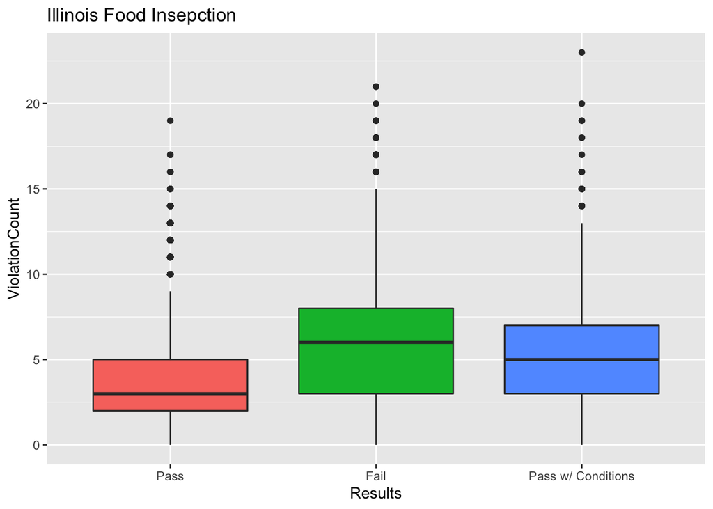

```r
# to compare the relationship between Results and ViolationCount, we need to first select buseinsses that have results as "Pass", "Fail", or "Pass w/ Conditions"
# then use a boxplot to show the location and variance among subgroups
data_violations %>%
  filter(Results == "Pass" | Results == "Fail" | Results == "Pass w/ Conditions") %>%
  ggplot(aes(x = Results, y = ViolationCount, fill = Results)) +
  geom_boxplot() +
  labs(title = "Illinois Food Insepction") +
  theme(legend.position = "none")
```

QUESTION 3

Based on this graph, the median ViolationCount for “Pass” is around 3, the median ViolationCount for “Fail” is around 6, and the median ViolationCount for “Pass w/ Conditions” is around 5.

If excluding outliers, we can see that 75% of the businesses that result in a “Pass” in Food Inspection have less than 5 ViolationCount, and 100% of the businesses that result in a “Pass” in Food Inspection have less than 9 ViolationCount.

For businesses that result in a “Fail”, 50% of which have 3 to 8 violations. And for businesses that result in a “Pass w/ Conditions”, 50% of which have 3 to 7 violations. However, based on this boxplot, it is hard to tell it there is a distinct difference in violation count between “Fail” and “Pass w/ Conditions”.